# Week 3 Maximum Likelihood: Theory

Author

Zhe Chen

# Why Likelihood $\bigstar$

Cost of OLS: never know *how Y is was generated,* only which line fits best

A line cannot fit all types of outcomes, e.g., binaries (0/1).

Maximum likelihood asks: **Which parameter values would have made the data I observed most likely?**

Pros of maximum likelihood:

- One method for any outcome: binary, count, ordered, duration.
- Standard errors from the shape of the likelihood, not a new formula per model.
- One way to test hypotheses, logit or Poisson alike: three tests read off the same curve.
- Nothing lost: with bell-shaped errors it returns the least-squares line exactly.

# The Likelihood

## Probability vs. Likelihood $\bigstar$

| Probability | Likelihood |
| --- | --- |
| $f(y\mid\theta)$ | $\mathcal{L}(\theta;y)\equiv f(y\mid\theta)$ |
| $\theta$ is fixed and know, $y$ varies | $y$ is fixed (your data), $\theta$ varies |
| If the parameter were $\theta$, how likely are different possible data values $y$? | Given the data we actually observed, which values of $\theta$ make those data more plausible? |

**Important**

The likelihood is the same formula read backwards: a function of $\theta$ with the data fixed. It is **not** a distribution over $\theta$: it **does not** integrate to one.

## Example: Marbles in a Bag

- An opaque bag holds blue and white marbles; $\theta$ is the proportion blue.
- You draw 10 marbles *with replacement* and get 7 blue.
- Ten draws are ten *observations*, each a Bernoulli outcome (blue or not); the summary “7 of 10” is a binomial count.

Build its probability:

- **One draw**: blue with probability $\theta$, white with probability $1-\theta$ (replacement makes the draws identical and independent).
- **One particular sequence,** say BBBBBBBWWW, independence means multiply $\theta \cdot \theta \cdots \theta \cdot (1-\theta)(1-\theta)(1-\theta)=\theta^7(1-\theta)^3$. Any other order with 7 blues and 3 whites has the **same** product.
- **All such sequences**: there are $\binom{10}{3}=\binom{10}{7}=\frac{10!}{3!7!}=120$ ways to place 3 whites (equivalently the 7 blues) among the 10 draws, so $\Pr(7\text{ blue}\mid\theta)=120\theta^7(1-\theta)^3$

**Tip**

$\binom{n}{k}$, read “$n$ choose $k$”. $\binom{n}{k} = \frac{n!}{(n-k)!k!}$

## Plot of the Likelihood

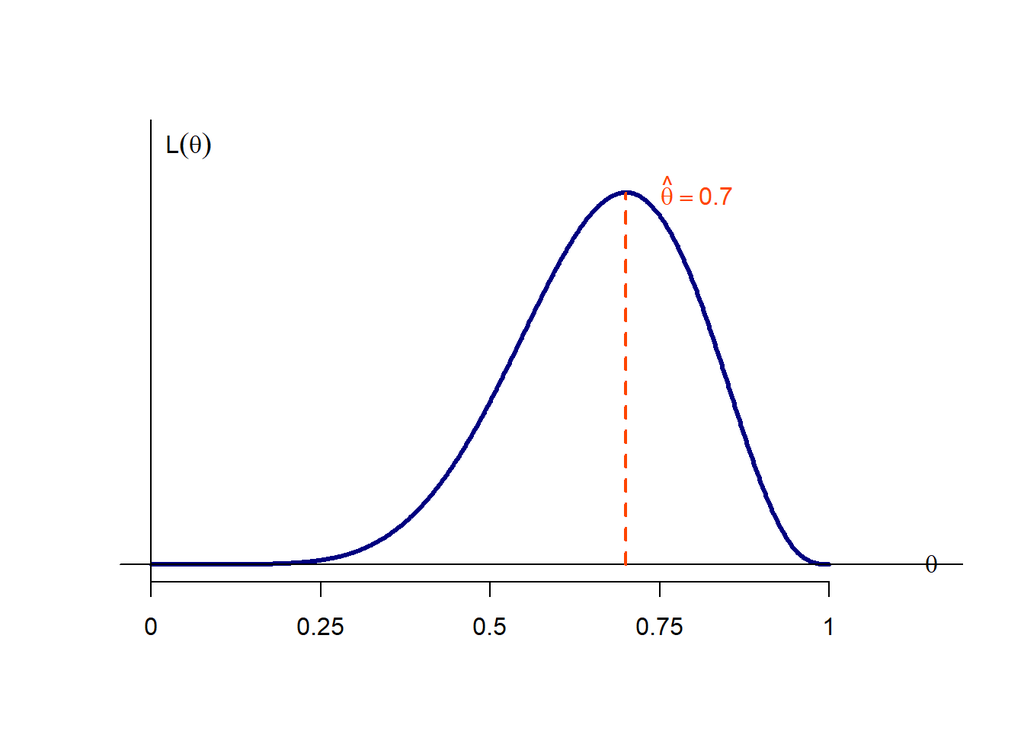

- The height at any $\theta$ is the probability of these data if that $\theta$ were true.
- The peak is the MLE (maximum likelihood estimate). The width the the peak measures uncertainty.

## Formula of Likelihood (Joint Density) $\bigstar$

If the $n$ observations are independent given $\theta$, their joint density:

$$\mathcal{L}(\theta;y_1,...,y_n) = \prod_{i=1}^n f(y_i\mid\theta)$$

**Tip**

Independence means $f(y_1, y_2 \mid \theta) = f(y_1 \mid \theta) f(y_2 \mid \theta)$

Take logs

$$\boxed{\ell(\theta) \equiv \log \mathcal{L}(\theta) = \sum_{i=1}^{n} \log f(y_i \mid \theta)}$$

**Tip**

$$\log_b(xy)=\log_b x+\log_b y$$
$$\log_b\left(\frac{x}{y}\right)=\log_b x-\log_b y$$
$$\log_b(x^k)=k\log_b x$$
$$log_b\left(\sqrt[k]{x}\right)=\frac{1}{k}\log_b x$$

- log is strictly increasing, so it does not move the maximum ($\arg\max_\theta \mathcal L(\theta)=\arg\max_\theta \ell(\theta)$)
- A product becomes a sum, so the derivative is a sum over observations: setting it to zero is a kind of averaging.

## Bernoulli $\bigstar$

$$f(y_i\mid \theta)=\theta^{y_i}(1-\theta)^{1-y_i}$$

$$\mathcal{L}(\theta)
=\prod_{i=1}^{n}\theta^{y_i}(1-\theta)^{1-y_i}
=\theta^{\sum_i y_i}(1-\theta)^{n-\sum_i y_i}$$

$$\ell(\theta)
=\left(\sum_i y_i\right)\log\theta
+\left(n-\sum_i y_i\right)\log(1-\theta)$$

## Binomial $\bigstar$

$$\Pr(Y=y \mid n,\theta)=\binom{n}{y}\theta^y(1-\theta)^{n-y},\qquad y=0,1,\ldots,n$$

$$\begin{aligned}
\mathcal{L}(\theta)&=\binom{n}{y}\theta^y(1-\theta)^{n-y}\\
\ell(\theta)&=\log\binom{n}{y}+y\log\theta+(n-y)\log(1-\theta)
\end{aligned}$$

## Poisson $\bigstar$

$$\Pr(Y=y\mid\theta)=\frac{\theta^y e^{-\theta}}{y!},\qquad y=0,1,2,\ldots$$

$$\begin{aligned}\mathcal{L}(\theta)&=\prod_{i=1}^{n}\frac{\theta^{y_i}e^{-\theta}}{y_i!}\\\ell(\theta)&=\sum_{i=1}^{n}\log\left(\frac{\theta^{y_i}e^{-\theta}}{y_i!}\right)\\&=\sum_{i=1}^{n}\left(y_i\log\theta-\theta-\log(y_i!)\right)\\&=\log(\theta)\sum_i y_i-n\theta-\sum_i \log(y_i!)\end{aligned}$$

**Important**

The mean and variance of Poisson distribution are both $\theta$.

## Normal Linear Model $\bigstar$

$$f(y \mid \mu,\sigma^2)=\frac{1}{\sqrt{2\pi\sigma^2}}\exp\left(-\frac{(y-\mu)^2}{2\sigma^2}\right)$$

When

1. **Linear CEF**: $\quad E[Y_i \mid X_i] = \beta_0 + \beta_1 X_i.$
2. **Normal Errors**: $\quad \epsilon_i \sim \mathcal{N}(0,\sigma^2)$, independently.

Then $Y_i \mid X_i \sim \mathcal{N}(\beta_0+\beta_1X_i,\sigma^2)$: the bell’s curve center $\mu$ is the line.

Put $\mu = b_0 + b_1X_i$ into the density, and one observation’s likelihood at candidate values ($b_0$, $b_1$) is

$$f(Y_i \mid b_0,b_1)=\frac{1}{\sqrt{2\pi\sigma^2}}\exp\left(-\frac{(Y_i-b_0-b_1X_i)^2}{2\sigma^2}\right)$$

### OLS is an MLE $\bigstar$

$$\begin{aligned}
\ell(b_0,b_1)
&=
\sum_{i=1}^{n}\log f(Y_i\mid b_0,b_1) \\
&=
\sum_{i=1}^{n}
\left[
-\frac{1}{2}\log(2\pi\sigma^2)
-\frac{(Y_i-b_0-b_1X_i)^2}{2\sigma^2}
\right] \\
&=
\underbrace{
-\frac{n}{2}\log(2\pi\sigma^2)
}_{\text{no }b_0,b_1}
-
\underbrace{
\frac{1}{2\sigma^2}
\sum_{i=1}^{n}(Y_i-b_0-b_1X_i)^2
}_{\text{Week 1's }S(b_0,b_1)}.
\end{aligned}$$

**Important**

Maximizing ℓ is exactly minimizing S, the MLE is the least-squares line.

Least squares was never arbitrary: it is what “make the data as probable as possible” prescribes for normal errors around a line.

**Warning**

OLS itself never needed normality. Normality entered only to make the t table exact.

Normality is only needed for MLE, but MLE extends to everything that OLS cannot do.

## Counting Data $\bigstar$

- Units out of a known $n$ → each is a Bernoulli, the total is binomial
- Units accumulate over exposure (no count, no ceiling) → Poisson

# Finding the MLE

## The Score Function $\bigstar$

The **score** is the derivative of the log-likelihood with respect to the parameter:

$$S(\theta)
\equiv
\frac{\partial \ell(\theta)}{\partial \theta}
=
\sum_{i=1}^{n}
\frac{\partial \log f(y_i \mid \theta)}{\partial \theta}.$$

- **First-order condition:** the MLE $\hat{\theta}$ solves $S(\hat{\theta}) = 0$.
- **Second-order condition:** $\partial^2\ell/\partial\theta^2 < 0$ at $\hat{\theta}$, so that we have a maximum rather than a minimum.
- Write $\theta_0$ for the *true* value. Across repeated samples, $E[S(\theta_0)] = 0$.

## Bernoulli: Deriving $\hat{\theta}$ $\bigstar$

$$\begin{aligned}
\ell(\theta)
&=
\left(\sum_i y_i\right)\log\theta
+
\left(n-\sum_i y_i\right)\log(1-\theta) \\
S(\theta)
&=
\frac{\sum_i y_i}{\theta}
-
\frac{n-\sum_i y_i}{1-\theta}
\overset{!}{=}0
\end{aligned}$$

Multiply through by $\theta(1-\theta)$:

$$\begin{aligned}
(1-\theta)\sum_i y_i
-
\theta\left(n-\sum_i y_i\right)
&= 0 \\
\sum_i y_i
-
\theta\sum_i y_i
-
n\theta
+
\theta\sum_i y_i
&= 0
\end{aligned}$$

$$\boxed{
\hat{\theta}
=
\frac{1}{n}\sum_i y_i
=
\bar y
}$$

## Poisson: Deriving $\hat{\theta}$ $\bigstar$

$$\ell(\theta)
=
\log(\theta)\sum_i y_i
-
n\theta
-
\sum_i \log(y_i!)$$

$$S(\theta)
=
\frac{\sum_i y_i}{\theta}
-
n$$

Set the score equal to zero:

$$S(\hat{\theta})=0
\quad\Longrightarrow\quad
\frac{\sum_i y_i}{\hat{\theta}}
=
n$$

$$\Longrightarrow\quad
\boxed{
\hat{\theta}
=
\frac{\sum_i y_i}{n}
=
\bar{y}
}$$

Second-order condition:

$$\frac{\partial^2 \ell}{\partial \theta^2}
=
-\frac{\sum_i y_i}{\theta^2}
<
0$$

## Linear Regression: Deriving $\hat{\beta}$ and $\hat{\sigma}^2$ $\bigstar$

Write $e_i=Y_i-b_0-b_1X_i$

Then

$$\ell(b_0,b_1,\sigma^2)=-\frac{n}{2}\log(2\pi\sigma^2)-\frac{1}{2\sigma^2}\sum_{i=1}^n e_i^2$$

$$\begin{aligned}
\frac{\partial\ell}{\partial b_0}
&=-\frac{1}{2\sigma^2}\sum_i 2e_i\frac{\partial e_i}{\partial b_0}\\
&=-\frac{1}{2\sigma^2}\sum_i2e_i(-1)\\
&=\frac{1}{\sigma^2}\sum_i e_i
\end{aligned}$$

$$\begin{aligned}
\frac{\partial\ell}{\partial b_1}
&=-\frac{1}{2\sigma^2}\sum_i2e_i\frac{\partial e_i}{\partial b_1}\\
&=-\frac{1}{2\sigma^2}\sum_i2e_i(-X_i)\\
&=\frac{1}{\sigma^2}\sum_iX_ie_i
\end{aligned}$$

**Note**

OLS normal equations

$$\begin{aligned}
\frac{\partial\ell}{\partial\sigma^2}
&=-\frac{n}{2\sigma^2}
-\frac{1}{2}\sum_i e_i^2\left(-\frac{1}{\sigma^4}\right)\\
&=-\frac{n}{2\sigma^2}
+\frac{1}{2\sigma^4}\sum_i e_i^2
\end{aligned}$$

Set $-\frac{n}{2\sigma^2}+\frac{1}{2\sigma^4}\sum_i e_i^2=0$

$$\boxed{\hat\sigma^2=\frac{1}{n}\sum_i\hat e_i^2}$$

**Warning**

The MLE of $\sigma^2$ is biased, for $e_i=Y_i-b_0-b_1X_i$

$$s^2_{OLS}=\frac{1}{n-2}\sum_{i=1}^n \hat e_i^2 = \sigma^2$$

$$E[\hat\sigma^2_{\text{MLE}}]=\frac{1}{n}\sum_i\hat e_i^2=\frac{n-2}{n}\sigma^2$$
So

$$E[\hat{\sigma}^2] = \frac{n-2}{n}\sigma^2 < \sigma^2$$

## Newton-Raphson

Most likelihoods like logit, probit, negative binomial, anything with covariates, have no algebraic solution to $S(\theta)=0$.

**Newton–Raphson**: Start at a guess $\theta^{[0]}$, and iterate

$$\theta^{[t+1]}
=
\theta^{[t]}
-
\left[
\left.
\frac{\partial^2 \ell}{\partial \theta^2}
\right|_{\theta^{[t]}}
\right]^{-1}
S\left(\theta^{[t]}\right)$$

Variants:

- **BFGS** approximates the second derivative
- **Fisher** scoring uses its expectation (what `glm()` does).

**NoteSteps of Newton-Raphson**

1. Guess $\theta^{[t]}$
2. $S_{\theta^{t}}$ (score function)
3. $\ell''_{\theta^{t}}$
4. $\theta^{t+1}=\theta^t-S_{\theta^t}/\ell''_{\theta^t}$

# Information

## Curvature Is Information $\bigstar$

The more negative the $\ell''$ is, the more information

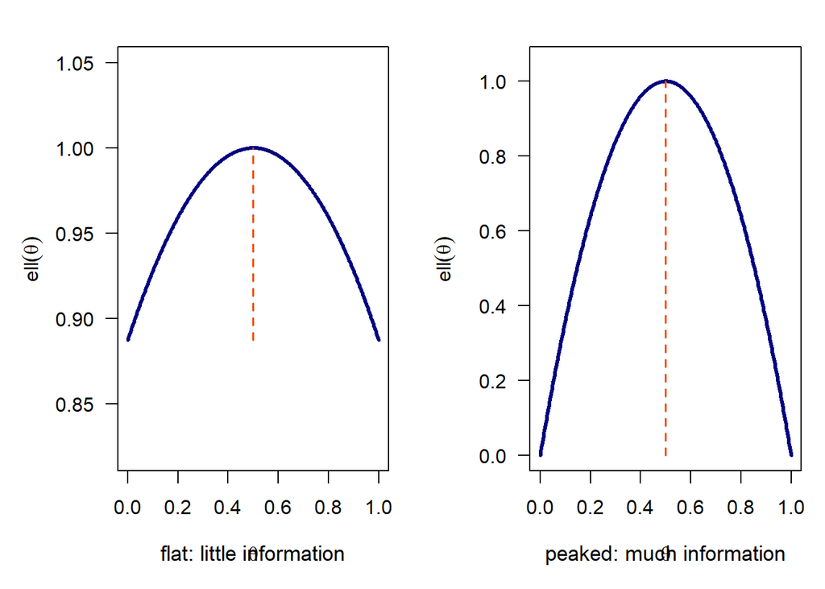

## Fisher Information $\bigstar$

At the true value $\theta_0$

$$\mathcal{I}(\theta_0)
\equiv
-E\!\left[\ell''(\theta_0)\right]
=
E\!\left[S(\theta_0)^2\right]
=
\operatorname{Var}\!\left(S(\theta_0)\right)$$

- **Information quality**: $-E\!\left[\ell''(\theta_0)\right]=E\!\left[S(\theta_0)^2\right]$ true if the model is right
- **Observed information:** $-\ell''(\theta_0)$, this is what the software reports
- **additive**: $\mathcal I_n=n\mathcal I_1$

**Note**

For independent observations:

$$\ell_n(\theta)=\sum_{i=1}^n \ell_i(\theta)$$

Differentiate twice:

$$\ell_n''(\theta)=\sum_{i=1}^n \ell_i''(\theta)$$

Fisher information is

$$\mathcal I_n(\theta_0)=-E[\ell_n''(\theta_0)]$$

Using linearity of expectation

$$\mathcal I_n(\theta_0)=-\sum_{i=1}^nE[\ell_i''(\theta_0)]$$

If the observations are identically distributed, each one contributes the same amount of information, $\mathcal{I}$ . Therefore,

$$\boxed{\mathcal I_n=n\mathcal I_1}$$

## The Variance of the MLE $\bigstar$

The variance is one over minus the second derivative of the log-likelihood at its peak.

$$\widehat{V}(\hat{\theta})
=
\left[
-\left.
\frac{\partial^2 \ell}{\partial \theta^2}
\right|_{\hat{\theta}}
\right]^{-1}
=
\frac{1}{\text{observed information}}$$

**Note**

That is the “familiar 1/n”:

$$\boxed{\operatorname{Var}(\hat\theta)\propto\frac{1}{n}}$$

And therefore the standard error behaves like

$$SE(\hat\theta)\propto\frac{1}{\sqrt n}$$

Intuition: **each independent observation contributes information;** $n$ **observations give** $n$ **times as much information, which makes variance shrink at rate** $1/n$ **and standard error shrink at rate** $1/\sqrt{n}$**.**

### Bernoulli Information

$$S(\theta)
=
\frac{\sum_i y_i}{\theta}
-
\frac{n-\sum_i y_i}{1-\theta},$$

$$\frac{\partial^2 \ell}{\partial \theta^2}
=
-\frac{\sum_i y_i}{\theta^2}
-
\frac{n-\sum_i y_i}{(1-\theta)^2}.$$
Taking expectations, using $E\left[\sum_i y_i\right]=n\theta$

$$\begin{aligned}
\mathcal{I}(\theta)
&=
\frac{n\theta}{\theta^2}
+
\frac{n(1-\theta)}{(1-\theta)^2} \\
&=
\frac{n}{\theta}
+
\frac{n}{1-\theta} \\
&=
\frac{n}{\theta(1-\theta)}.
\end{aligned}$$

$$\operatorname{Var}(\hat{\theta})
=
\mathcal{I}(\theta)^{-1}
=
\frac{\theta(1-\theta)}{n}.$$

### Poisson Information

$$\frac{\partial^2 \ell}{\partial \theta^2}
=
-\frac{\sum_i y_i}{\theta^2}
\quad\Longrightarrow\quad
\mathcal{I}(\theta)
=
\frac{E\left[\sum_i y_i\right]}{\theta^2}
=
\frac{n\theta}{\theta^2}
=
\frac{n}{\theta},$$

so

$$\operatorname{Var}(\hat{\theta})
=
\frac{\theta}{n},
\qquad
\widehat{V}(\hat{\theta})
=
\frac{\bar{y}}{n}.$$

# Properties

As $n \to \infty$

1. **Consistency** $\bigstar$: $\hat{\theta}\xrightarrow{p}\theta_0$.
2. **Asymptotic normality** $\bigstar$: $\hat{\theta}\overset{a}{\sim}\mathcal{N}(\theta_0,\mathcal{I}(\theta_0)^{-1})$.
3. Asymptotic efficiency (not evaluated): if the model is right, no other well-behaved estimator has a smaller asymptotic variance
4. Invariance (not evaluated): if $\hat{\theta}$ is the MLE of $\theta$, then $c(\hat{\theta})$ is the MLE of $\theta$ for any function $c(\cdot)$. Implication: the MLE of the odds is the odds of the MLE.

**Important**

The first three are asymptotic.

Invariance, by contrast, holds exactly in any sample.

# Testing

General idea: **Is the null value** $\theta_0$ **far from the peak** $\hat{\theta}$

## Z-score (Walder) test $\bigstar$

$$Z = \frac{\hat{\theta}-\theta_0}{\operatorname{se}(\hat{\theta})}, \qquad se(\hat{\theta}) = \frac{1}{\mathcal{I_\theta}}$$
reject if $|z| > 1.96$ ($\alpha = 0.05$). This is what `summary(glm)` reports.

$$W = Z^2 = \mathcal{I}(\hat{\theta}-\theta_0)^2, \quad \mathcal{I}= -\ell''(\hat{\theta})$$

reject if $W > 3.84$ ($\alpha = 0.05$).

**Tip**

The distribution of $Z^2$ or $W$ is $\chi_1^2$

## Likelihood Ratio $\bigstar$

$$LR = 2[\ell(\hat{\theta})-\ell(\theta_0)]$$

with q restrictions, $LR \xrightarrow{d}\chi_q^2$

## Three Rulers $\bigstar$

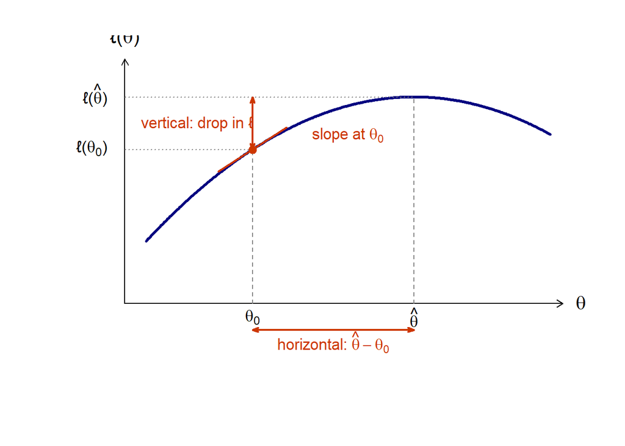

1. **Horizontal (Wald/z-test):** the gap $\hat{\theta}-\theta_0$
2. **Vertical (likelihood ratio):** the fit lost by moving from $\hat{\theta}$ down to $\theta_0$
3. **Slope (score):** at peak it is zero

Both the first two rulers are compared with $\chi^2$. When $\ell$ is a parabola, they agree exactly.

**Note**

$$\begin{aligned}
\ell(\theta)
&=
\ell(\hat{\theta})
-
\frac{1}{2}\mathcal{I}(\theta-\hat{\theta})^2
&& \text{the parabola: peak at }\hat{\theta}\text{, curvature }-\mathcal{I}
\\
\ell(\hat{\theta})-\ell(\theta_0)
&=
\frac{1}{2}\mathcal{I}(\hat{\theta}-\theta_0)^2
&& \text{plug in }\theta=\theta_0\text{: the drop}
\\
LR
&=
2\times \text{drop}
=
\mathcal{I}(\hat{\theta}-\theta_0)^2
=
W
&& \text{doubling undoes the }\frac{1}{2}
\end{aligned}$$

If $\ell$ is not parabola,
$$\ell(\theta)\neq\ell(\hat{\theta})-
\frac{1}{2}\mathcal{I}(\theta-\hat{\theta})^2$$

## What Software Reports $\bigstar$

- `summary(glm)` z-statstics and p-values: **Wald**
- `anova(m0, m1, test = "Chisq")` the deviance: **likelihood ratio**

**When Wald and LR disagree, use LR.**

## What to Report in Practice $\bigstar$

- **One coefficient, large n, an ordinary variable:** `summary()` the Wald z and p. At large n, Wald z equals LR.
- **A block:** `anova(m0, m1, test = "Chisq"`. LR
- **A rare outcome, a small group, a huge standard error, a coefficient near a boundary:** never use Wald z

## AIC and BIC $\bigstar$

$$AIC = -2\ell(\hat{\theta}) + 2k$$

$$BIC = -2\ell(\hat{\theta}) + k\log{n}$$

- **Lower is better**
- No null model, no p-value, the models need not to be nested

### BIC and LR: more $\bigstar$

- **Why BIC**: it asks “whether a term worth its place”

**ImportantLarge n Rejects Everything with LR**

LR grows with n for any effect that is not exactly zero, but BIC penalizes a large n

- **Reading BIC:**
  - 0-2 weak
  - 2-6 positive
  - 6-10 strong
  - >10 very strong
- **When LR is needed:** for nested models
- They cannot decide which controls to hold constant.

**TipRule of Thumb**

**Nested models** and one focused hypothesis: LR

A **menu of competing models** of competing models: BIC

Every model should be estimated on the **same observations** when comparing LR, BIC, AIC, or log-likelihoods